# Global Minimum Volatility portfolio (GMV) on an equity portfolio

2023-10-20

# 1. Introduction

## 1.1 Packages

We import the necessary libraries to perform the first analysis.

1. library(tidyverse): The tidyverse package constitutes a collection of R packages meticulously designed to work seamlessly in unison for data manipulation, visualization, and analysis. It encompasses packages like ggplot2 for data visualization, dplyr for data manipulation, tidyr for data tidying, and more. Loading tidyverse avails all these packages for utilization during your R session, streamlining your data analysis workflow.
2. library(quantmod): The quantmod package primarily caters to quantitative financial modeling and analysis. It furnishes an array of functions and tools for handling financial data, such as downloading and managing stock price data, conducting technical analysis, and modeling financial time series.
3. library(DataExplorer): The DataExplorer package serves the purpose of preliminary data exploration and analysis. It offers functions to generate summary statistics, visualize missing data, plot variable distributions, and more. It can aid in obtaining a quick overview of your data before delving into more extensive analyses.
4. library(corrplot): The corrplot package specializes in visualizing correlation matrices. It provides functions for generating visually appealing and informative correlation plots, which prove valuable for comprehending relationships between variables within your data.
5. library(scales): The scales package provides an assortment of scales and formatting functions tailored for R graphics. It is often employed in conjunction with other plotting packages, such as ggplot2, to customize the appearance of plots, including axes, labels, and color scales.

```r
library(tidyverse)
library(quantmod)
```

```r
library(DataExplorer)
library(corrplot)
library(scales)
```

## 1.2 Investment universe

In our portfolio management project, we have carefully chosen a set of twenty stocks from a larger universe of investments. This selection represents the most significant companies in the US equity market, primarily based on their market capitalization. By analyzing these stocks, our objective is to gain valuable insights into the strategies that can be employed for managing investments in the US equity market.

Our choice of stocks is guided by several key considerations:

- Investment universe: Our selection is drawn from a universe of stocks that encompasses twenty well-established companies within the US equity market. These companies are known for their substantial market presence and are recognized leaders in their respective industries.
- Market capitalization focus: We have chosen stocks with an emphasis on market capitalization. Larger market capitalization often indicates stability and lower volatility, making these stocks appealing for various investment strategies.
- US equity market perspective: Our project primarily targets insights related to the US equity market. The chosen stocks provide a representative snapshot of the investment landscape in one of the world’s largest and most influential equity markets.
- Diversification: To create a well-rounded portfolio, we have ensured diversification across different sectors and industries. Diversification is essential in portfolio management as it spreads risk and mitigates overexposure to a single sector.
- Market visibility: The selected companies are not only well-regarded in the financial sector but are also widely recognized in popular culture. Their performance is closely monitored, and they often hold significant sway over market indices.
- Historical data and research: These stocks have a rich history of performance data and have been the subject of extensive research. Access to their historical data is abundant, making them suitable for rigorous portfolio management analysis and research.

The provided R code defines the stock tickers for these companies, allowing you to access financial data. This data can then be employed to conduct a range of analyses, such as return calculations, risk assessments, and portfolio optimization, to test and implement various investment strategies on the US equity market.

```r
# Define the stock tickers you want to fetch data for
stock_tickers <- c("AAPL", "MSFT", "GOOGL", "AMZN", "TSLA", "NVDA", "PYPL", "CMCSA", "ADBE", "ASML",
                   "CSCO", "PEP", "AVGO", "TMUS", "INTC", "TXN", "AMGN", "NFLX", "SBUX", "AMAT")
```

```r
# Fetch historical stock data from Yahoo Finance
start_date <- "2019-01-01"  # Replace with your desired start date
end_date <- "2023-08-31"    # Replace with your desired end date
stock_data <- getSymbols(stock_tickers, from = start_date, to = end_date, auto.assign = TRUE)
```

## 1.3 Data cleaning

We perform some formatting to clean the data, an important step in performing data analysis:

- Extracting Adjusted Closing Prices: lapply(stock_tickers, function(ticker) { Ad(get(ticker)) }): This code uses the lapply function to retrieve the adjusted closing prices (often used for return calculations) for a list of stock tickers. It iterates through each ticker in the stock_tickers vector and fetches the adjusted closing prices using the Ad() function from the quantmod package.
- Combining Stock Returns: do.call(cbind, stock_returns): The code combines the extracted adjusted closing prices into a single data frame by calling cbind (column-bind) on the list of stock returns obtained in the previous step. This creates a data frame where each column represents the adjusted closing prices of a specific stock.
- Renaming Columns: colnames(fin_prices) <- stock_tickers: The code assigns the stock tickers as column names to the combined data frame. This step ensures that each column is labeled with the corresponding stock ticker, making it easier to identify each stock’s data.
- Handling Missing Data: na.omit(fin_prices): This line of code removes rows with missing values (usually represented as NA) from the combined data frame, fin_prices. Removing missing data is a common preprocessing step to ensure the quality and consistency of the dataset for further analysis.

```r
# Extract adjusted closing prices (which are typically used for returns)
stock_returns <- lapply(stock_tickers, function(ticker) {
  Ad(get(ticker))
})

# Combine stock returns into a single data frame
fin_prices <- do.call(cbind, stock_returns)

# Rename columns to match your analysis
colnames(fin_prices) <- stock_tickers

# Eliminated missing data in time series
fin_return <- na.omit(fin_prices)  # Remove rows with missing values
```

We perform the arithmetic return method to compute returns for this data set. It is simple, intuitive and widely accessible. Arithmetic returns are particularly useful for performance measurement, providing a clear view of actual gains and losses. It is well-suited for short-term analysis and offer transparency.

```r
arith_fin_returns = diff(fin_return)/lag(fin_return)
head(arith_fin_returns, n=3)
```

```
##                   AAPL        MSFT       GOOGL       AMZN        TSLA
## 2019-01-02          NA          NA          NA         NA          NA
## 2019-01-03 -0.09960724 -0.03678807 -0.02769565 -0.0252415 -0.03147171
## 2019-01-04  0.04268911  0.04650945  0.05129358  0.0500640  0.05769739
##                   NVDA        PYPL       CMCSA        ADBE        ASML
## 2019-01-02          NA          NA          NA          NA          NA
## 2019-01-03 -0.06041693 -0.04268226 0.007855797 -0.03949775 -0.05515059
## 2019-01-04  0.06406746  0.05091973 0.033775810  0.04863239  0.04326918
##                   CSCO          PEP         AVGO         TMUS        INTC
## 2019-01-02          NA           NA           NA           NA          NA
## 2019-01-03 -0.03636795 -0.009333897 -0.088951085 -0.003677681 -0.05501264
## 2019-01-04  0.04504505  0.020506357  0.009828606  0.037988332  0.06136177
##                    TXN        AMGN       NFLX        SBUX        AMAT
## 2019-01-02          NA          NA         NA          NA          NA
## 2019-01-03 -0.05897301 -0.01521631 0.01322577 -0.04337687 -0.05794501
## 2019-01-04  0.04522945  0.03418354 0.09723449  0.03315462  0.06848443
```

```r
arith_fin_returns <- arith_fin_returns[-1, ]
```

In order to ensure that the data is properly imported, with non missing valiues and proper data cleaning procedure, we can implement this line of code in order to learn more about data.

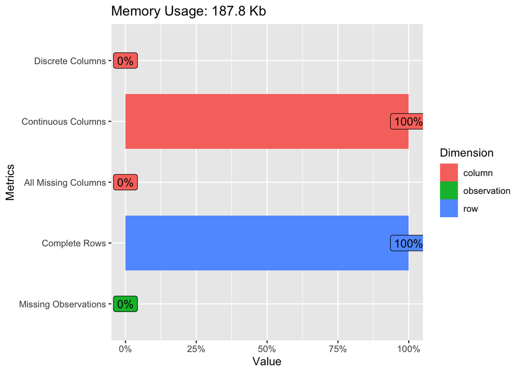

```r
plot_intro(arith_fin_returns)
```

From the figure below, Tesla’s stock (TICKER: TSLA) witnessed an unprecedented surge in attraction, making it a notable standout within our investment universe.

Tesla’s performance distinctly outpaced the broader investment universe. The surge in retail trading interest for the electric car company can explain to some extent this massive performance, especially in the wake of the post-COVID market, where intensive monetary policies prompted significant investments from both corporate and retail investors seeking higher yields.

The code allowed us to plot returns into a time series, providing a clear visualization of stock performance during the specified period.

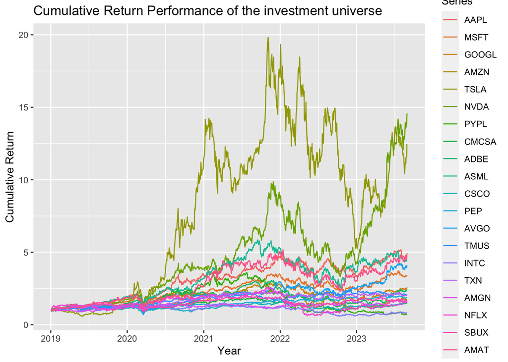

```r
# Calculate Cumulative Returns
cumulative_returns <- cumprod(1 + arith_fin_returns)

# Plot Cumulative Return Performance
library(ggplot2)
autoplot(cumulative_returns, facets = NULL) +
  ggtitle("Cumulative Return Performance of the investment universe") +
  ylab("Cumulative Return") +
  xlab("Year")
```

We can define the minimum volatility portfolio as a portfolio of assets with the lowest possible risk for an investor and is located on the far-left side of the efficient frontier. Note that the minimum volatility portfolio is also called the minimum variance portfolio or more precisely the global minimum volatility portfolio (to distinguish it from other optimal portfolios obtained for higher risk levels).

To implement to global minimum variance portfolio, we need to compute the covariance matrix as an input parameter for the Markowitz optimization model.

```r
cov_matrix <- cov(arith_fin_returns)
```

Correlation plays an important role in a Markowitz allocation framework, where diversification can be achieved when allocating capital to poorly or negatively correlated assets.

The concept of diversification seeks to enhance returns while minimizing risk by investing in a variety of assets that will react differently to the same event (s). For example, whenever there is unfavorable news about a certain event, i.e. 2008 subprime mortgage crisis, the stock market typically declines dramatically. Simultaneously, the same news has generally benefited the price of specific assets, such as gold. As a result, portfolio diversification should include not just diverse stocks inside and outside of the same industry, but also diverse asset classes, such as bonds and commodities. The diversification effect is a term that relates to the link between portfolio correlations and diversification. When there is an imperfect correlation between assets (positive or negative), the diversification effect occurs. It is a critical and successful risk mitigation method since risk mitigation may be accomplished without sacrificing profits. As a result, any prudent investor who is ‘risk cautious’ will diversify to a certain extent.

Here, we observe opportunities for diversification within our investment universe. For instance, we notice that stocks often categorized as defensive plays can serve as effective diversification instruments when combined with more aggressive stocks. In this context, consider Amgen Inc. (TICKER: AMGN) in the healthcare industry, which exhibits a neutral correlation when compared to a stock like Tesla (TICKER: TSLA). Similar logic applies to a stock such as PepsiCo Inc. (TICKER: PEP) in relation to Tesla. It’s worth noting that within our investment universe, we do not find negative correlations, as all the assets exhibit some degree of correlation to one another.

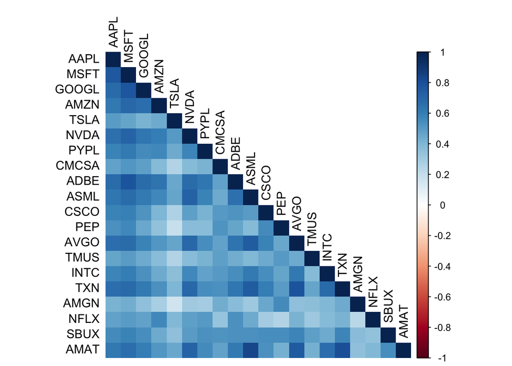

```r
corrplot(cor(arith_fin_returns), type='lower',
         method = "shade", tl.col = 'black', cl.pos = "r", tl.cex = 1)
```

To further complement the analysis of the data gathered, we can run a statistical analysis of the first moments of the distribution to assess the performance of each stock and understand their behavior during the timeframe observed. NB: Figures obtained from this statistical analysis are given on a daily return basis.

```r
summary(arith_fin_returns)
```

```
##      Index                 AAPL                MSFT
##  Min.   :2019-01-03   Min.   :-0.128647   Min.   :-0.147390
##  1st Qu.:2020-03-04   1st Qu.:-0.008324   1st Qu.:-0.008514
##  Median :2021-05-03   Median : 0.001423   Median : 0.001101
##  Mean   :2021-05-01   Mean   : 0.001580   Mean   : 0.001240
##  3rd Qu.:2022-06-30   3rd Qu.: 0.012965   3rd Qu.: 0.011377
##  Max.   :2023-08-30   Max.   : 0.119808   Max.   : 0.142169
##      GOOGL                AMZN                 TSLA
##  Min.   :-0.116341   Min.   :-0.1404944   Min.   :-0.210628
##  1st Qu.:-0.008504   1st Qu.:-0.0109222   1st Qu.:-0.017579
##  Median : 0.001013   Median : 0.0009821   Median : 0.002178
##  Mean   : 0.001012   Mean   : 0.0007304   Mean   : 0.003009
##  3rd Qu.: 0.011129   3rd Qu.: 0.0120408   3rd Qu.: 0.023022
##  Max.   : 0.096202   Max.   : 0.1353590   Max.   : 0.198949
##       NVDA                PYPL                CMCSA
##  Min.   :-0.184521   Min.   :-0.2459044   Min.   :-0.0913073
##  1st Qu.:-0.015158   1st Qu.:-0.0139465   1st Qu.:-0.0079128
##  Median : 0.003060   Median : 0.0010063   Median : 0.0006984
##  Mean   : 0.002838   Mean   : 0.0001388   Mean   : 0.0005144
##  3rd Qu.: 0.020068   3rd Qu.: 0.0139848   3rd Qu.: 0.0095184
##  Max.   : 0.243696   Max.   : 0.1410978   Max.   : 0.1256442
##       ADBE                ASML                CSCO
##  Min.   :-0.167932   Min.   :-0.173492   Min.   :-0.1373035
##  1st Qu.:-0.010223   1st Qu.:-0.011637   1st Qu.:-0.0075006
##  Median : 0.001809   Median : 0.001160   Median : 0.0005941
##  Mean   : 0.001035   Mean   : 0.001622   Mean   : 0.0005255
##  3rd Qu.: 0.013235   3rd Qu.: 0.016426   3rd Qu.: 0.0088840
##  Max.   : 0.177193   Max.   : 0.145732   Max.   : 0.1337348
##       PEP                  AVGO                TMUS
##  Min.   :-0.1142831   Min.   :-0.199129   Min.   :-0.1120879
##  1st Qu.:-0.0049846   1st Qu.:-0.010200   1st Qu.:-0.0078173
##  Median : 0.0006834   Median : 0.001450   Median : 0.0008011
##  Mean   : 0.0006349   Mean   : 0.001479   Mean   : 0.0007958
##  3rd Qu.: 0.0065279   3rd Qu.: 0.013311   3rd Qu.: 0.0095050
##  Max.   : 0.1293660   Max.   : 0.158337   Max.   : 0.1178280
##       INTC                 TXN                  AMGN
##  Min.   :-0.1804153   Min.   :-0.1182572   Min.   :-8.261e-02
##  1st Qu.:-0.0111179   1st Qu.:-0.0103407   1st Qu.:-7.367e-03
##  Median : 0.0002335   Median : 0.0007668   Median :-4.019e-05
##  Mean   : 0.0001528   Mean   : 0.0008089   Mean   : 5.045e-04
##  3rd Qu.: 0.0120074   3rd Qu.: 0.0122601   3rd Qu.: 7.933e-03
##  Max.   : 0.1952131   Max.   : 0.1352941   Max.   : 1.090e-01
##       NFLX                 SBUX                 AMAT
##  Min.   :-0.3511660   Min.   :-0.1620424   Min.   :-0.203576
##  1st Qu.:-0.0137289   1st Qu.:-0.0083444   1st Qu.:-0.014175
##  Median : 0.0007823   Median : 0.0006783   Median : 0.001367
##  Mean   : 0.0008648   Mean   : 0.0006439   Mean   : 0.001764
##  3rd Qu.: 0.0146454   3rd Qu.: 0.0093758   3rd Qu.: 0.018498
##  Max.   : 0.1685434   Max.   : 0.1473032   Max.   : 0.128131
```

In portfolio management, statistical analysis can help understand financial patterns in data.

Second, QQ plots, or quantile-quantile plots, are utilized to evaluate whether a dataset adheres to a specific theoretical distribution, such as the normal distribution. These plots help portfolio managers identify departures from expected distributions, facilitating informed investment decisions. Together, these techniques aid in the exploration and assessment of financial data, enabling portfolio managers to make more informed and data-driven choices in their investment strategies.

We can run some more advanced statistical analysis to understand the asset return behavior of the equities selected in this analysis.

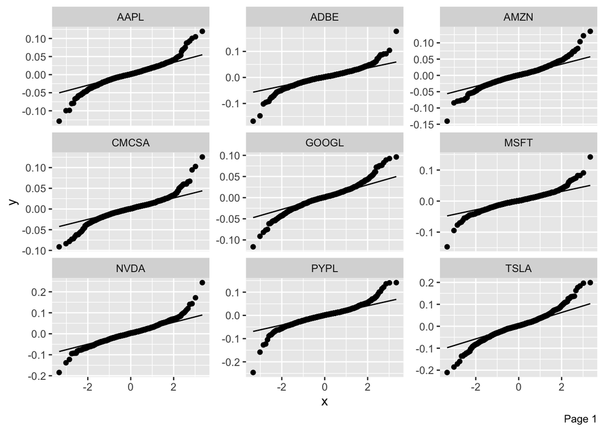

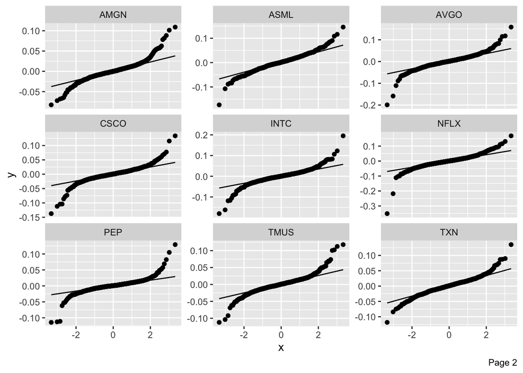

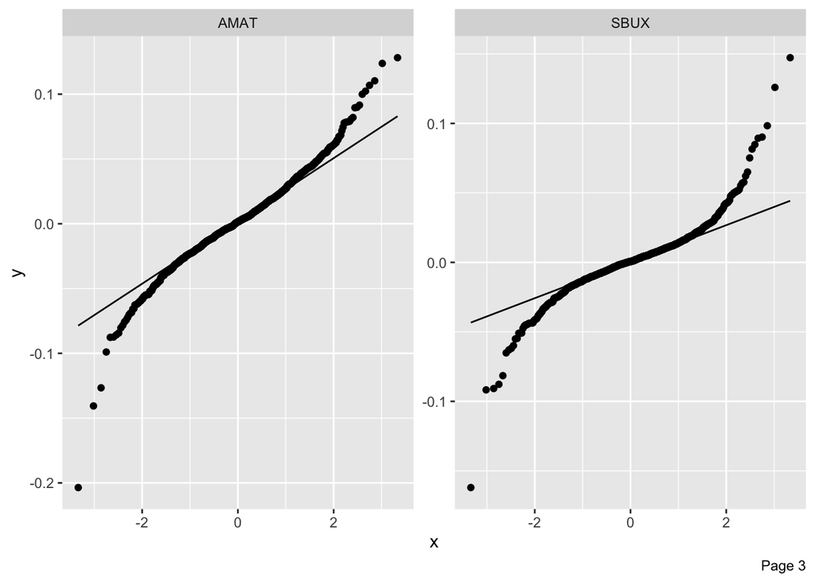

```r
# Advanced statistical analysis for the dataset

#plot_density(arith_fin_returns)
plot_qq(arith_fin_returns)
```

# 2. Modelling part

Modern Portfolio Theory (MPT) is founded on several market and investor assumptions. Several of these assumptions are stated explicitly, while others are implied. Markowitz’s contributions to (MPT) in portfolio selection are based on the following basic assumptions:

- Investors are rational (they seek to maximize returns while minimizing risk, or minimize risk while maximize return).
- Investors will accept increased risk only if compensated with higher expected returns.
- Investors receive all relevant information regarding their investment decision.
- Investors can borrow or lend an unlimited amount of capital at a risk-free rate of interest.

## 2.1 Unbiased Global Minimum Variance (GMV) portfolio

In the context of time series data analysis, one of the crucial applications is the division of the data set into a training set and a testing set based on temporal order. This approach is particularly important when dealing with data that evolves over time, such as stock prices, weather observations, or economic indicators.

The training set typically comprises historical data, while the testing set contains more recent observations. This temporal separation allows for the evaluation of predictive models and forecasting techniques. By using historical data to train the model and then assessing its performance on more recent data, analysts can gauge the model’s ability to make accurate predictions and anticipate future trends. Time series data applications are essential in fields like finance, where understanding and forecasting trends over time is important.

For the purpose of modelling, we will shrink the data set into two different sub-samples. We can define the following parameters:

```r
num_rows_subsample1 <- 400
total_rows <- nrow(arith_fin_returns)
```

1. The first sub-sample will cover the first 400 trading days covered in the data set.

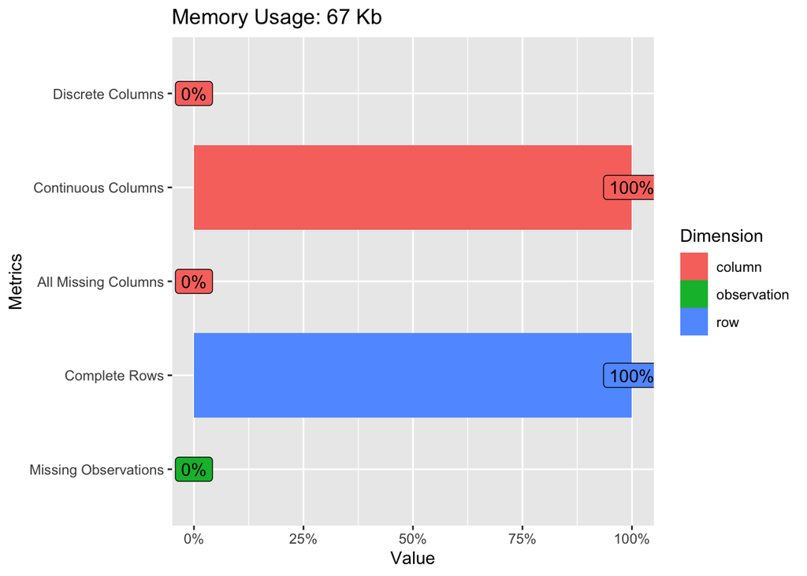

```r
subsample1 <- arith_fin_returns[1:num_rows_subsample1, ]
plot_intro(subsample1)
```

2. The second sub-sample will cover the rest of the data set, covering the equivalent of 773 trading days.

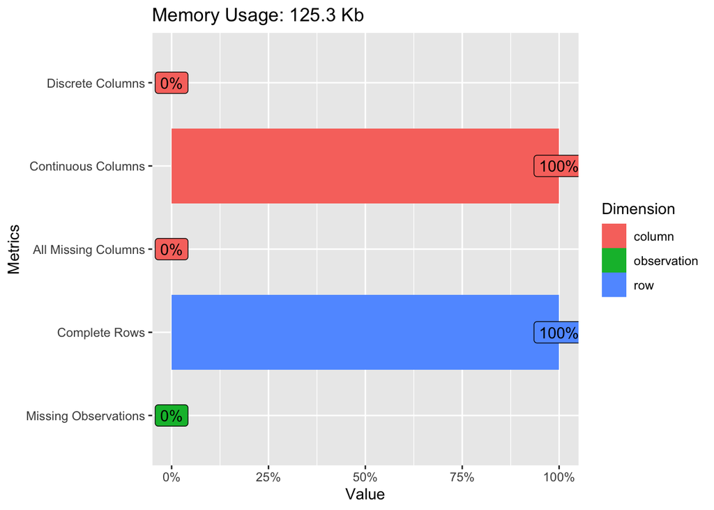

```r
subsample2 <- arith_fin_returns[(num_rows_subsample1 + 1):total_rows, ]
plot_intro(subsample2)
```

We implement the parameters of the model in order to compute the GMV:

```r
#Definition of parameters
n <- ncol(subsample1)
T <- nrow(subsample1)
e <- rep(1, n)
perio <- 12

#Compute Sigma (unbiased covariance matrix)
Sigma <- cov(subsample1) * (T - 1) / (T - n - 2) * perio
C <- t(e) %*% solve(Sigma) %*% e

#Anticipated volatility can be computed
sigmag <- sqrt(1 / C)
```

After computing the parameters required to implement the unbiased GMV portfolio, we can compute omega, representing the weightings of the portfolio as follows.

```r
omega_gmv <- 1 / as.numeric(C) * solve(Sigma) %*% e
```

We can see in this instance that the portfolio is mixed, with some long and short positions. The capital is fully invested, with some important exposure in the long part of the portfolio on stocks like Amazon (TICKER: AMZN) with 39.85%, followed by PepsiCo (TICKER: PEP) at 29.45% and ASML (TICKER: ASML) at 26.35%.

On the short part of the portfolio, we can see an important short on three stocks that can stand out: Applied Materials Inc. (TICKER: AMAT) -24.07%, Adobe (TICKER: ADBE) at -19.90% and NVIDIA Corp. (TICKER: NVDIA) at -18.28%.

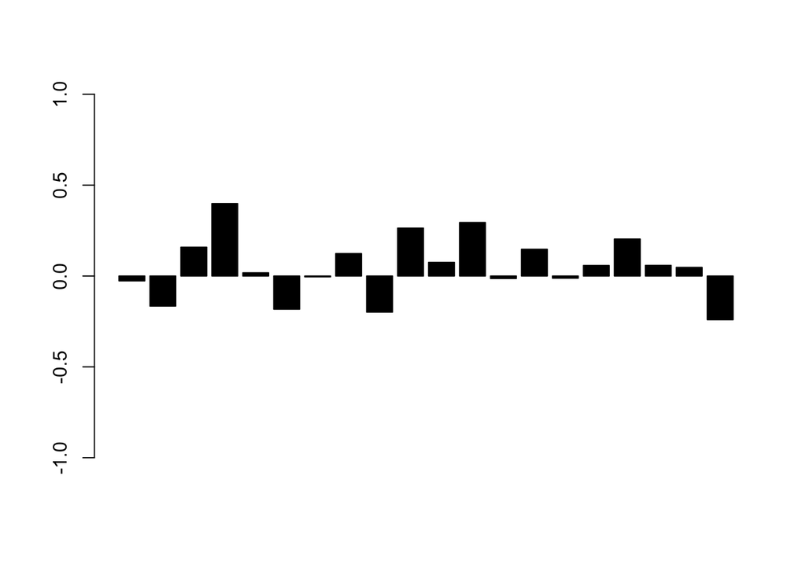

```r
barplot(as.numeric(omega_gmv), col = 'black', ylim = c(-1, 1))
```

## 2.2 Implementation of Principal Component Analysis (PCA)

Principal Component Analysis (PCA) is a technique used to analyze and reduce the dimensionality of a dataset while retaining as much variance as possible. We perform the PCA analysis using the second subsample starting from the trading day number 401 of the sample to the trading day number 1174.

```r
pca_result <- prcomp(subsample2, center = TRUE, scale = TRUE)

#Extract principal component loadings
loadings <- pca_result$rotation

#Variance explained by each principal component
var_explained <- (pca_result$sdev^2) / sum(pca_result$sdev^2)

#We select the number of components for the PCA
num_components <- 3  # Adjust as needed

#We compute the weights of the PCA in the portfolio.
weights_pca <- loadings[, 1:num_components] / rowSums(loadings[, 1:num_components])
```

This is the result of the plot from the PCA analysis. In the context of your PCA results for the twenty US equity stocks, here are some interpretations:

1. **Principal Components (PCs)**:
   - PC1, PC2, and PC3 represent the first, second, and third principal components, respectively.
   - Each principal component is a linear combination of the original variables (in this case, stocks) such that it captures the maximum variance in the data. PC1 captures the most variance, followed by PC2, and so on.
2. **Loadings**:
   - Loadings represent the coefficients that define the contribution of each original variable (stock) to the principal component. The loadings are specific to each PC.
   - Positive or negative values in loadings indicate the direction and strength of the relationship between each stock and the principal component. For example, a high positive loading indicates that a particular stock has a strong positive influence on the corresponding principal component.
3. **Weights for the PCA Portfolio**:
   - The weights for the PCA portfolio represent the portfolio allocation to each stock based on the chosen principal components. These weights can be used to create a portfolio with a specific strategy, which leverages the information in the principal components.
   - In your code, you’ve selected the first three principal components (num_components = 3), and you’ve calculated the weights for each stock based on these components.
4. **Interpretation**:
   - PC1, PC2, and PC3 capture specific patterns or relationships in the returns of the stocks. For example, PC1 might capture broad market movements, while PC2 might capture sector-specific trends.
   - The specific interpretation of each PC depends on the loadings and how they relate to the original variables (stocks). Positive loadings indicate stocks that move in the same direction as the principal component, while negative loadings suggest stocks that move in the opposite direction.
   - By examining the loadings for each PC, you can gain insights into which stocks are the most influential for each component.

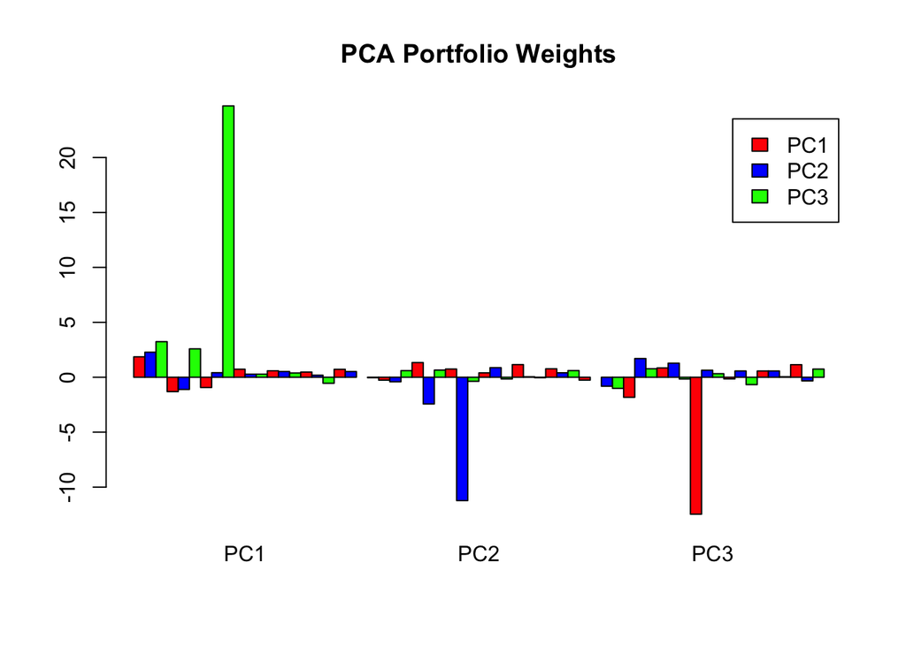

```r
my_colors <- c("red", "blue", "green") # vector of colours
barplot(weights_pca, beside = TRUE, col = my_colors,
        names.arg = colnames(weights_pca),
        legend.text = colnames(weights_pca),
        main = "PCA Portfolio Weights")
```